# Project_Loan_Part_2 slides

## Part II - Factors that cause loan defaults

### by (Salvage Ajibade)

## Investigation Overview

In this investigation, I wanted to look at the characteristics of borrowers that could be used to predict if they will default a loan. The main focus was on these features: Income, Borrower rate, Borrower state, Debt to income ratio and Credit Scores.

## Dataset Overview

The data consisted of borrower information and attributes for 113,937 loans. The attributes included CreditGrade, LoanStatus,occupation,employment status, borrower state, EmploymentStatusDuration,IsBorrowerHomeowner, IncomeRange, CreditScoreRangeLower, CreditScoreRangeUpper, BorroweRate and 70 other variables. Only 15 variables were investigated.From the selected features, i created new variables such as : Credit Sore, Income and occupational classes( sectors of occupations). I also focused on only 6 states in the dataset.

## Distribution of Loan Status

The loan status indicates where your loan is in terms of payment.

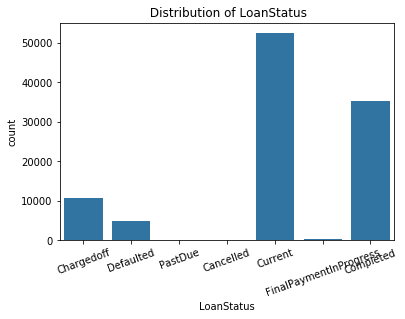

### Distribution of Income

The distribution of monthly income across the borrowers seems to be discrete since the data provided Income ranges instead of Income. Most of the borrowers earn more than $37,499.

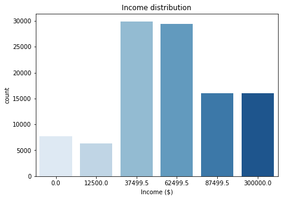

### Distribution of borrower State

This is the state each borrower is from. Most borrowers seem to be from California while the fewest of them are from Georgia

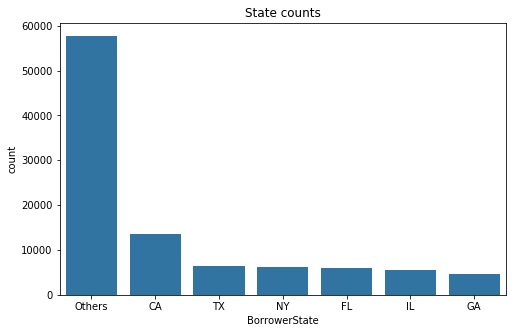

### Credit score by borrower rate

The borrower rate is the amount of interest a borrower has to pay with a loan. A Credit Score is a form of grade that indicates how well a borrower repays the loan. The plot shows a slight correlation between Credit Score and borrower rate, indicating that high Credit scores have lower borrower rates.

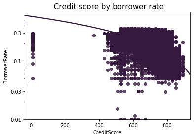

### Debt to income ratio by state , loan status & income

The Debt-to-income ratio (DTI) compares how much you owe each month to how much you earn. We can see here that the state withthe highesT DTI is Georgia(GA).Most borrowers with more than 10,000 income have a very low debttoincome ratio. Also high debt ratios can be linked to high Defaults and Charge offs Loan Status and low income.

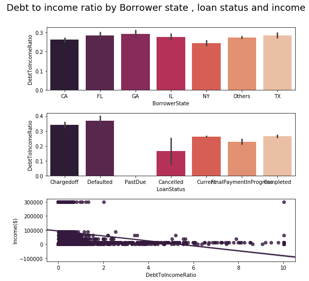

### BorrowerRates & Loan Status in different States

The borrower rates for defaulted and charged off loans seem to be very high in each state. Texas happens to have the highest number of defaults here in terms of borrower rates.

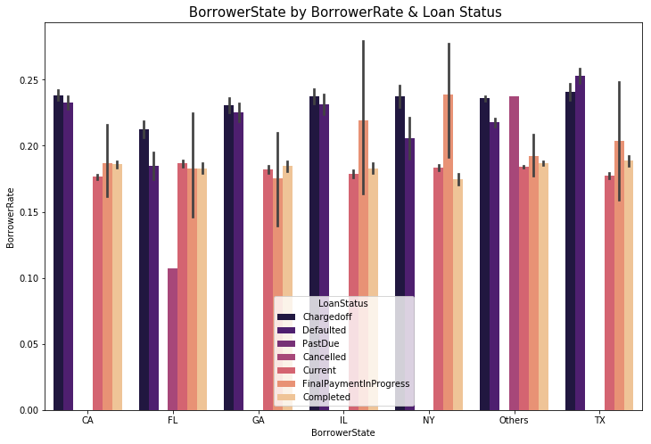

### Loan Status and CreditScores in various States

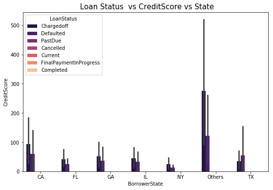